# IODS-course project

# Logistic regression

*Exercise 3* *There are two data set that was analyzed in this exercise.*

```r
alc<-read.csv('C:/Users/Henna/OneDrive/Asiakirjat/OPEN SCIENCE/IODS-project/data/alc.csv')

colnames(alc)
```

```
##  [1] "school"     "sex"        "age"        "address"    "famsize"
##  [6] "Pstatus"    "Medu"       "Fedu"       "Mjob"       "Fjob"
## [11] "reason"     "nursery"    "internet"   "guardian"   "traveltime"
## [16] "studytime"  "failures"   "schoolsup"  "famsup"     "paid"
## [21] "activities" "higher"     "romantic"   "famrel"     "freetime"
## [26] "goout"      "Dalc"       "Walc"       "health"     "absences"
## [31] "G1"         "G2"         "G3"         "alc_use"    "high_use"
```

*The data set used in this exercise was student achievement in secondary education of two Portuguese schools. The data attributes include student grades, demographic, social and school related features) and it was collected by using school reports and questionnaires. Two datasets are provided regarding the performance in two distinct subjects: Mathematics (mat) and Portuguese language (por). In [Cortez and Silva, 2008], the two datasets were modeled under binary/five-level classification and regression tasks. More about this dataset in URL: https://archive.ics.uci.edu/ml/datasets/Student+Performance*

*How four different variables have relationship with alcohol consumption? I chose 4 interesting variables from the data to research this more closely: sex, age, health and family size.Variables: sex - student’s sex (binary: ‘F’ - female or ‘M’ - male), age - student’s age (numeric: from 15 to 22), health - current health status (numeric: from 1 - very bad to 5 - very good),famsize - family size (binary: ‘LE3’ - less or equal to 3 or ‘GT3’ - greater than 3). I think that sex does have relation to alcohol consumption, because if alcohol is more approved for example in group of men then the consumption can be higher too. Also, the age has strong relation, since it is illegal to use alcohol under certain age, and also younger people might like more partying than older people. I think health has strong relation to alcohol consumption. When health is greater close to 5, the alcohol consumption is lower. I don’t think the last variable family size has relation to alcohol consumption.*

*Now I will explore graphically the variables I chosen to analyze.*

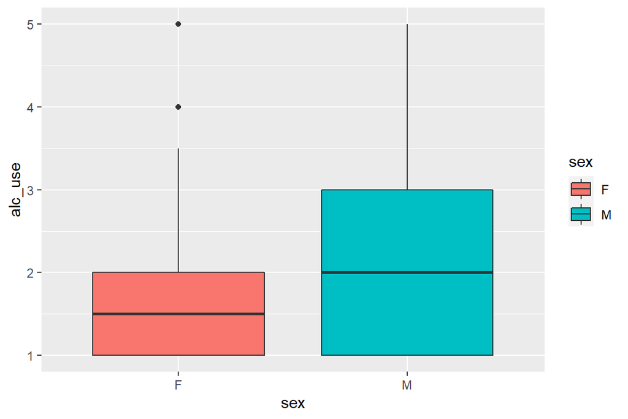

```r
alc_use<-alc$alc_use
age<-alc$age
gender<-alc$sex
G3<-alc$G3
library(ggplot2)

qplot(sex, alc_use, data=alc, geom="boxplot", fill=sex)
```

*The first plot is from relationship between gender and alcohol consumption. It shows that gender has effect to alcohol consumption as I assumed too. It seems, that males(mean = 2) has larger alcohol consumption than females (mean= 1.5). Males has also wider distribution range(from minimum to maximum) of alcohol consumption from values 1 to 5, when females distribution is from 1 to 3.5.*

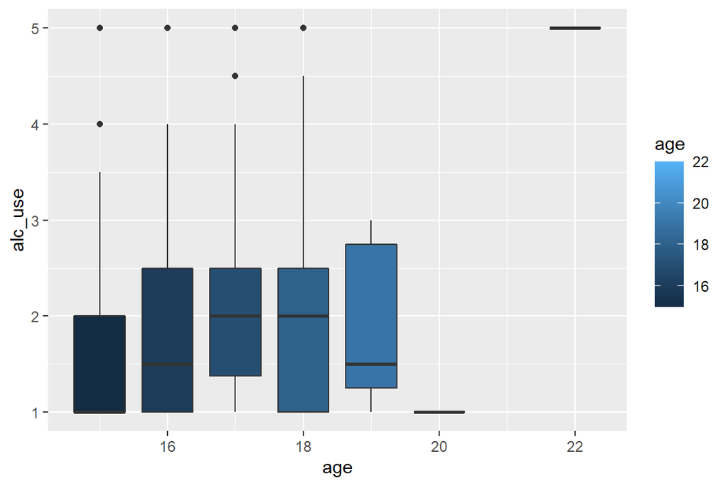

```r
qplot(age, alc_use, data=alc, aes(group=age), geom="boxplot", fill=age)
```

*The second plot is from relationship between age and alcohol consumption. It can be seen that mean alcohol consumption increases from age 16 to 18; from mean value 1.5 to 2. Mean alcohol consumption decreases at age of 19. After age of 19, there does not occur enough data to make more analysis. My hypothesis was that younger people has greater alcohol consumption, however there are no enouh data from older people to verify this hypothesis.*

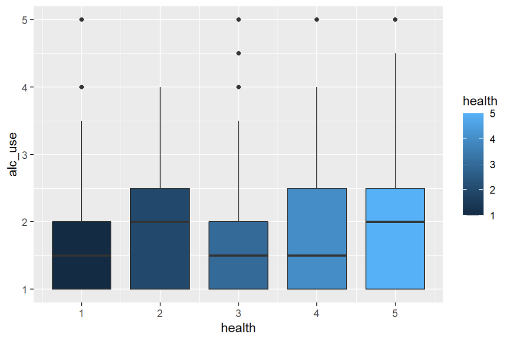

```r
qplot(health, alc_use, data=alc, aes(group=health), geom="boxplot", fill= health)
```

*The third plot is from relationship between health and alcohol consumption. My hypothesis was that better better heath correlates with lower consumption of alcohol. However, the boxplot does not show any significant correlations in this case, when the mean value is almost same in every heath state.*

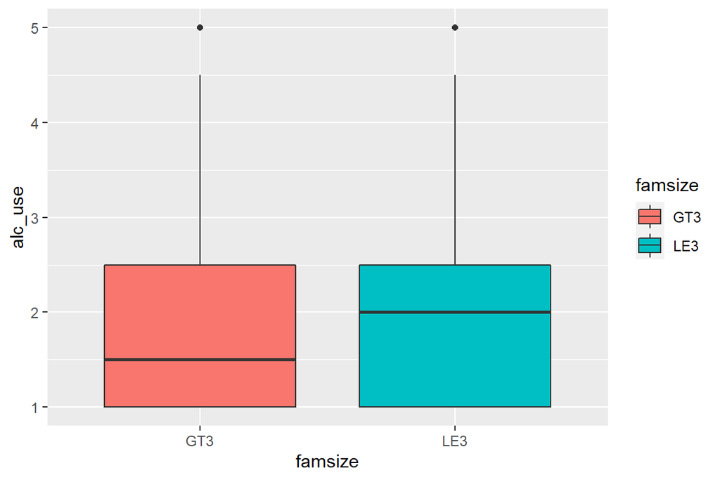

```r
qplot(famsize, alc_use, data=alc, geom="boxplot", fill= famsize)
```

*Logistic regression model*

```r
# find the mode with glm()
library(magrittr)
model <- glm(high_use ~ health + age + sex+ famsize, data = alc, family = "binomial")
summary(model)
```

```
##
## Call:
## glm(formula = high_use ~ health + age + sex + famsize, family = "binomial",
##     data = alc)
##
## Deviance Residuals:
##     Min       1Q   Median       3Q      Max
## -1.3194  -0.8577  -0.6809   1.2320   1.9759
##
## Coefficients:
##             Estimate Std. Error z value Pr(>|z|)
## (Intercept) -5.44209    1.70428  -3.193 0.001407 **
## health       0.07604    0.08540   0.890 0.373210
## age          0.22766    0.09796   2.324 0.020126 *
## sexM         0.83640    0.23566   3.549 0.000386 ***
## famsizeLE3   0.29775    0.25317   1.176 0.239558
## ---
## Signif. codes:  0 '***' 0.001 '**' 0.01 '*' 0.05 '.' 0.1 ' ' 1
##
## (Dispersion parameter for binomial family taken to be 1)
##
##     Null deviance: 465.68  on 381  degrees of freedom
## Residual deviance: 443.62  on 377  degrees of freedom
## AIC: 453.62
##
## Number of Fisher Scoring iterations: 4
```

```r
coef(model)
```

```
## (Intercept)      health         age        sexM  famsizeLE3
## -5.44208711  0.07604261  0.22766201  0.83639503  0.29774674
```

```r
# compute odds ratios (OR)
OR <- coef(model) %>% exp
# compute confidence intervals (CI)
CI <- confint(model) %>% exp
# print out the odds ratios with their confidence intervals
cbind(OR, CI)
```

```
##                      OR        2.5 %    97.5 %
## (Intercept) 0.004330436 0.0001445247 0.1173832
## health      1.079008551 0.9141475250 1.2786256
## age         1.255660856 1.0377394401 1.5253758
## sexM        2.308031569 1.4600095587 3.6835354
## famsizeLE3  1.346820645 0.8157128841 2.2052926
```

```r
library(dplyr)
# predict() the probability of high_use
probabilities <- predict(model, type = "response")
# add the predicted probabilities to 'alc'
alc <- mutate(alc, probability = probabilities)
# use the probabilities to make a prediction of high_use
alc <- mutate(alc, prediction = probability > 0.5)
# tabulate the target variable versus the predictions
table(high_use = alc$high_use, prediction = alc$prediction)
```

```
##         prediction
## high_use FALSE TRUE
##    FALSE   258   10
##    TRUE    105    9
```